[figure not shown]

[OHI British Columbia](http://www.ohibc.org/) | [OHI Science](http://ohi-science.org) | [Citation policy](https://github.com/OHI-Science/ohiprep/releases)

# Set up ocean area raster and MPA pct rasters

Compiled on Wed Sep 12 10:12:45 2018 by ohara

```r
knitr::opts_chunk$set(fig.width = 6, fig.height = 4, fig.path = 'Figs/',
                      echo = TRUE, message = FALSE, warning = FALSE)

library(raster)
library(sf)
library(fasterize)

source('https://raw.githubusercontent.com/oharac/src/master/R/common.R')  ###
  ### includes library(tidyverse); library(stringr); dir_M points to ohi directory

dir_git <- '~/github/spp_risk_dists'

### goal specific folders and info
dir_setup   <- file.path(dir_git, 'setup')
dir_spatial <- file.path(dir_git, 'spatial')
dir_anx     <- file.path(dir_M, 'git-annex')
dir_o_anx   <- file.path(dir_O, 'git-annex/spp_risk_dists')
# ### provenance tracking
# library(provRmd); prov_setup()

### support scripts
source('~/github/src/R/rast_tools.R')
  ### raster plotting and analyzing scripts
```

# 1 Summary

To define spatial areas more accurately, create rasters of WDPA and ocean area at Gall-Peters resolution of 1 km^2. These can then be aggregated back to Gall Peters 10 km^2 working rasters, summing the total ocean area and total protected area within each working cell.

# 2 Data Sources

### 2.0.1 WDPA

# 3 Methods

## 3.1 Ocean area raster

- Project Natural Earth 10M oceabn polygons into Gall-Peters equal area projection
- rasterize at 1 km resolution
- aggregate up to 10 km resolution,

### 3.1.1 Create a 10 km^2 Gall Peters projection cell ID raster

```r
ocean_area_file <- file.path(dir_spatial, 'ocean_area_rast.tif')
cell_id_file    <- file.path(dir_spatial, 'cell_id_rast.tif')
ocean_1km_file  <- file.path(dir_o_anx, 'spatial', 'ocean_1km.tif')

if(!file.exists(ocean_area_file)) {

  ocean_sf_wgs84 <- read_sf(file.path(dir_spatial, 'ne_10m_ocean', 'ne_10m_ocean.shp'))

  ### Annoyingly, this counts the Caspian Sea as ocean... so make a block,
  ### cut it out, and go from there.
  caspian_block <- matrix(c(45, 35, 45, 48, 56, 48, 56, 35, 45, 35),
                          ncol = 2, byrow = TRUE)
  caspian_sf <- st_polygon(list(caspian_block)) %>%
    st_sfc(crs = 4326)

  ocean_sf <- ocean_sf_wgs84 %>%
    st_difference(caspian_sf) %>%
    st_transform(gp_proj4)


  bbox_ocean <- st_bbox(ocean_sf)
  ext_r  <- extent(bbox_ocean$xmin, bbox_ocean$xmax, bbox_ocean$ymin, bbox_ocean$ymax)
  rast_base_1km <- raster(ext_r, crs = crs(gp_proj4), res = 1000)
  rast_base_10km <- raster(ext_r, crs = crs(gp_proj4), res = 10000)

  if(!file.exists(ocean_1km_file)) {
    rast_ocean_1km <- fasterize(ocean_sf, rast_base_1km,
                              field = NULL,   ### all polygons given value of 1
                              background = 0) ### all non-polygons given value of 0
    writeRaster(rast_ocean_1km,
                ocean_1km_file,
                progress = 'text')
  } else {
    rast_ocean_1km <- raster(ocean_1km_file)
  }

  rast_ocean_10km <- raster::aggregate(rast_ocean_1km,
                                     fact = 10,   ### factor of 10 aggregation
                                     fun = mean,  ### mean of 1s (ocean) and 0s (land)
                                     progress = 'text')

  rast_ocean_area <- rast_ocean_10km * 100 ### multiply by 100 km^2 per cell
  values(rast_ocean_area)[values(rast_ocean_area) < 0.005] <- NA

  writeRaster(rast_ocean_area, ocean_area_file, overwrite = TRUE)
}

if(!file.exists(cell_id_file)) {
  rast_cell_id <- raster(ocean_area_file) %>%
    setValues(1:ncell(.))

  writeRaster(rast_cell_id, cell_id_file)
}
```

## 3.2 Create WDPA MPA percent protection data frame

Because we are rasterizing the protected areas down to the CHI raster resolution, we risk dropping any MPAs smaller than about 1 km^2. We assume these are not likely to have a significant impact on biodiversity protection.

### 3.2.1 Create WDPA map at GP 1 km^2 resolution

Actually, create two maps: one by protection category, another by year for no-take only (categories Ia, Ib, II, and no-take).

```r
rast_cell_id    <- raster(cell_id_file)
rast_ocean_1km  <- raster(ocean_1km_file)

wdpa_marine_file <- file.path(dir_o_anx, 'wdpa/wdpa_mar_by_cat_jun2018_1km2.tif')
wdpa_poly_file   <- file.path(dir_o_anx, 'wdpa/wdpa_jun2018/WDPA_June2018-shapefile-polygons.shp')

if(!file.exists(wdpa_marine_file)) {

  wdpa_poly <- sf::read_sf(wdpa_poly_file)

  # wdpa_poly$IUCN_CAT %>% unique()
  iucn_cats <- c('Ia'  = 1,
                 'Ib'  = 1,
                 'II'  = 2,
                 'III' = 3,
                 'IV'  = 4,
                 'V'   = 5,
                 'VI'  = 6)
  # wdpa_poly$STATUS %>% table()
       # Adopted   Designated  Established    Inscribed Not Reported     Proposed
       #      34       215853            2          241          128         1537
  # wdpa_poly$NO_TAKE %>% unique()
  # x <- wdpa_poly %>% filter(NO_TAKE %in% c('All', 'Part'))

  wdpa_marine <- wdpa_poly %>%
    filter(MARINE > 0 | GIS_M_AREA > 0) %>%
    filter(STATUS %in% c('Designated', 'Adopted', 'Established')) %>%
      ### no paper parks!
    filter(!str_detect(tolower(MANG_PLAN), 'non-mpa')) %>%
      ### omit non-MPA fisheries or species management plans!
    mutate(NO_TAKE = ifelse(WDPAID == 309888, TRUE, NO_TAKE),
             ### patch PIPA to be no take - currently "not reported"
           no_take = (NO_TAKE == 'All') | (NO_TAKE == 'Part' & NO_TK_AREA > 0.75 * GIS_M_AREA),
             ### if NO_TK_AREA is 75% or more of GIS area, count it...
           cat = iucn_cats[IUCN_CAT],
           cat = ifelse(no_take & !cat %in% 1:2, -1, cat), ### use -1 as a "no take" flag
           cat = ifelse(is.na(cat), 8, cat)) %>%           ### use 8 as an "other protected" flag
    arrange(cat) %>%
    st_transform(crs = gp_proj4)

  ### rasterize all protected areas to 1 km global raster;
  ### use min value: will prioritize no-take and higher levels of protection
  wdpa_all_rast_1km <- fasterize::fasterize(sf = wdpa_marine,
                                        raster = rast_ocean_1km,
                                        field  = 'cat',
                                        fun    = 'min')

  values(rast_ocean_1km)[values(rast_ocean_1km) < .005] <- NA
  wdpa_marine_rast_1km <- mask(wdpa_all_rast_1km, rast_ocean_1km)

  writeRaster(wdpa_marine_rast_1km, wdpa_marine_file,
              progress = 'text',
              overwrite = TRUE)

}

# git_prov(wdpa_poly_file, 'input')
# git_prov(wdpa_marine_file, 'output') ### even in "if", mask() won't prov-register it.
```

```r
rast_cell_id    <- raster(cell_id_file)
rast_ocean_1km  <- raster(ocean_1km_file)

wdpa_prot_yr_file <- file.path(dir_o_anx, 'wdpa',
                               'wdpa_mar_by_prot_yr_jun2018_1km2.tif')

if(!file.exists(wdpa_prot_yr_file)) {

  wdpa_poly <- sf::read_sf(wdpa_poly_file)

  # wdpa_poly$IUCN_CAT %>% unique()
  iucn_cats <- c('Ia'  = 1,
                 'Ib'  = 1,
                 'II'  = 2,
                 'III' = 3,
                 'IV'  = 4,
                 'V'   = 5,
                 'VI'  = 6)
  # wdpa_poly$STATUS %>% table()
       # Adopted   Designated  Established    Inscribed Not Reported     Proposed
       #      34       215853            2          241          128         1537
  # wdpa_poly$NO_TAKE %>% unique()
  # x <- wdpa_poly %>% filter(NO_TAKE %in% c('All', 'Part'))

  wdpa_no_take <- wdpa_poly %>%
    filter(MARINE > 0 | GIS_M_AREA > 0) %>%
    filter(STATUS %in% c('Designated', 'Adopted', 'Established')) %>%
      ### no paper parks!
    filter(!str_detect(tolower(MANG_PLAN), 'non-mpa')) %>%
      ### omit non-MPA fisheries or species management plans!
    mutate(NO_TAKE = ifelse(WDPAID == 309888, TRUE, NO_TAKE),
             ### patch PIPA to be no take - currently "not reported"
           no_take = (NO_TAKE == 'All') | (NO_TAKE == 'Part' & NO_TK_AREA > 0.75 * GIS_M_AREA),
             ### if NO_TK_AREA is 75% or more of GIS area, count it...
           cat = iucn_cats[IUCN_CAT],
           cat = ifelse(no_take & !cat %in% 1:2, -1, cat), ### use -1 as a "no take" flag
           cat = ifelse(is.na(cat), 8, cat)) %>%           ### use 8 as an "other protected" flag
    arrange(cat) %>%
    filter(cat <= 2) %>% ### this limits to categories Ia, Ib, II, and no-take
    st_transform(crs = gp_proj4)

  ### rasterize all protected areas to 1 km global raster;
  ### use min value: will prioritize no-take and higher levels of protection
  wdpa_all_rast_1km <- fasterize::fasterize(sf = wdpa_no_take,
                                        raster = rast_ocean_1km,
                                        field  = 'STATUS_YR',
                                        fun    = 'min')

  values(rast_ocean_1km)[values(rast_ocean_1km) < .005] <- NA
    ### in case of floating point not-quite-zeros...
  wdpa_yr_rast_1km <- mask(wdpa_all_rast_1km, rast_ocean_1km)

  writeRaster(wdpa_yr_rast_1km, wdpa_prot_yr_file,
              progress = 'text',
              overwrite = TRUE)

}

# git_prov(wdpa_poly_file, 'input')
# git_prov(wdpa_prot_yr_file, 'output')
```

### 3.2.2 Crosstab WDPA map to cell IDs

We can’t simply aggregate upwards here, since we need to keep track of different protection levels (for the first) and year (for the second).

```r
wdpa_marine_rast_1km <- raster(wdpa_marine_file)
rast_cell_id    <- raster(cell_id_file)    ### cell IDs at 10 km^2
rast_ocean_1km  <- raster(ocean_1km_file)  ### ocean presence at 1 km^2
rast_ocean_area <- raster(ocean_area_file) ### ocean proportional area at 10 km^2

cell_id_1km_file <- file.path(dir_o_anx, 'spatial/cell_id_1km.tif')

### Need a 1 km raster of cell IDs for crosstabbing...
if(!file.exists(cell_id_1km_file)) {
  rast_cell_id_1km <- resample(rast_cell_id, rast_ocean_1km,
                             progress = 'text',
                             filename = cell_id_1km_file,
                             method = 'ngb',
                             overwrite = TRUE)
} else {
  rast_cell_id_1km <- raster(cell_id_1km_file)
}

wdpa_cell_area_file <- file.path(dir_spatial, 'wdpa_mpa_area.csv')

### now break into chunks and mclapply across them to crosstab WDPA categories to cell IDs
if(!file.exists(wdpa_cell_area_file)) {
  ### Break into smaller chunks for faster processing and eventual parallelizing
  n_chunks <- 30

  crosstab_chunk <- function(rast1, rast2, chunk, n_chunks) {
    ### chunk <- 30
    chunk_size <- ceiling(ncol(rast1) / n_chunks)
    left_bound <- (chunk - 1) * chunk_size + 1
    right_bound <- min(left_bound + chunk_size, ncol(rast1))

    chunk_ext <- extent(rast1, 1, nrow(rast1), left_bound, right_bound)
    message('Processing ', chunk, ': ', paste0(as.character(round(chunk_ext)), collapse = ', '))
    wdpa_chunk    <- crop(rast1, chunk_ext)
    cell_id_chunk <- crop(rast2, chunk_ext)

    wdpa_cells <- crosstab(wdpa_chunk, cell_id_chunk,
                                    progress = 'text',
                                    long = TRUE) %>%
      setNames(c('wdpa_category', 'cell_id', 'n_prot')) %>%
      mutate(wdpa_category = as.integer(as.character(wdpa_category)),
             cell_id       = as.integer(as.character(cell_id)))
        ### wdpa_category and cell_id are crosstabbed as factors - first
        ### convert to character (to unfactorize it) then to integer.  Otherwise
        ### you end up with factor index, not actual cell ID or category.

    return(wdpa_cells)
  }

  ### Use the function in an mclapply call
  system.time({
    wdpa_cells_list <- parallel::mclapply(1:n_chunks, mc.cores = 16,
      FUN = function(x) crosstab_chunk(wdpa_marine_rast_1km,
                                       rast_cell_id_1km,
                                       chunk = x, n_chunks))
  #     user   system  elapsed
  # 1184.324  814.096  208.082
  })

  wdpa_cells_df <- bind_rows(wdpa_cells_list)

  area_df <- data.frame(cell_id  = values(rast_cell_id),
                           area_km2 = values(rast_ocean_area))

  wdpa_area_df <- wdpa_cells_df %>%
    full_join(area_df, by = 'cell_id') %>%
    filter(!is.na(wdpa_category)) %>%
    mutate(prot_area_km2 = n_prot, ### count of cells in 1 km^2 raster
           mpa_pct = prot_area_km2 / area_km2) %>%
    select(wdpa_category, cell_id, mpa_pct, prot_area_km2)
      ### mpa pct is relative to *ocean* area - not *total cell* area

  write_csv(wdpa_area_df, wdpa_cell_area_file)

} else {
  # git_prov(wdpa_cell_area_file, 'output')
}
```

```r
wdpa_yr_rast_1km <- raster(wdpa_prot_yr_file)
rast_cell_id    <- raster(cell_id_file)    ### cell IDs at 10 km^2
rast_ocean_1km  <- raster(ocean_1km_file)  ### ocean presence at 1 km^2
rast_ocean_area <- raster(ocean_area_file) ### ocean proportional area at 10 km^2

cell_id_1km_file <- file.path(dir_o_anx, 'spatial/cell_id_1km.tif')
rast_cell_id_1km <- raster(cell_id_1km_file)

wdpa_cell_year_file <- file.path(dir_spatial, 'wdpa_mpa_year.csv')

### now break into chunks and mclapply across them to crosstab WDPA categories to cell IDs
if(!file.exists(wdpa_cell_year_file)) {
  ### Break into smaller chunks for faster processing and eventual parallelizing
  n_chunks <- 30

  crosstab_chunk2 <- function(rast1, rast2, chunk, n_chunks) {
    ### chunk <- 30
    chunk_size <- ceiling(ncol(rast1) / n_chunks)
    left_bound <- (chunk - 1) * chunk_size + 1
    right_bound <- min(left_bound + chunk_size, ncol(rast1))

    chunk_ext <- extent(rast1, 1, nrow(rast1), left_bound, right_bound)
    message('Processing ', chunk, ': ', paste0(as.character(round(chunk_ext)), collapse = ', '))
    wdpa_chunk    <- crop(rast1, chunk_ext)
    cell_id_chunk <- crop(rast2, chunk_ext)

    wdpa_cells <- crosstab(wdpa_chunk, cell_id_chunk,
                                    progress = 'text',
                                    long = TRUE) %>%
      setNames(c('mpa_year', 'cell_id', 'n_prot')) %>%
      mutate(mpa_year = as.integer(as.character(mpa_year)),
             cell_id  = as.integer(as.character(cell_id)))
        ### mpa_year and cell_id are crosstabbed as factors - first
        ### convert to character (to unfactorize it) then to integer.  Otherwise
        ### you end up with factor index, not actual cell ID or category.

    return(wdpa_cells)
  }

  ### Use the function in an mclapply call
  system.time({
    wdpa_cells_list <- parallel::mclapply(1:n_chunks, mc.cores = 16,
      FUN = function(x) crosstab_chunk2(wdpa_yr_rast_1km,
                                        rast_cell_id_1km,
                                        chunk = x, n_chunks))
  #     user   system  elapsed
  # 1184.324  814.096  208.082
  })

  wdpa_cells_df <- bind_rows(wdpa_cells_list)

  area_df <- data.frame(cell_id  = values(rast_cell_id),
                        area_km2 = values(rast_ocean_area))

  wdpa_year_df <- wdpa_cells_df %>%
    full_join(area_df, by = 'cell_id') %>%
    filter(!is.na(mpa_year)) %>%
    mutate(prot_area_km2 = n_prot, ### count of cells in 1 km^2 raster
           mpa_pct = prot_area_km2 / area_km2) %>%
    select(mpa_year, cell_id, mpa_pct, prot_area_km2)
      ### mpa pct is relative to *ocean* area - not *total cell* area

  write_csv(wdpa_year_df, wdpa_cell_year_file)

} else {
  # git_prov(wdpa_cell_year_file, 'output')
}
```

### 3.2.3 View WDPA protected area proportions as raster

Proportional protection can be multiplied by ocean area raster to get area of protection. Collect by category (to avoid duplicate “by” values):

- No Take (categories 1 & 2 and specifically designated “no take”)
  - classified as 1, 2, and -1 respectively
- Conservation (categories 1-4 plus no take)
  - classified as 1, 2, 3, 4, and -1 (no take)
- All protection (non-NA)
  - classified as 1-6, -1 (no take), and 8 (other protection)

Note: these are not saved as separate rasters at this point… they are easily created from the dataframe of cell ID to protected proportion.

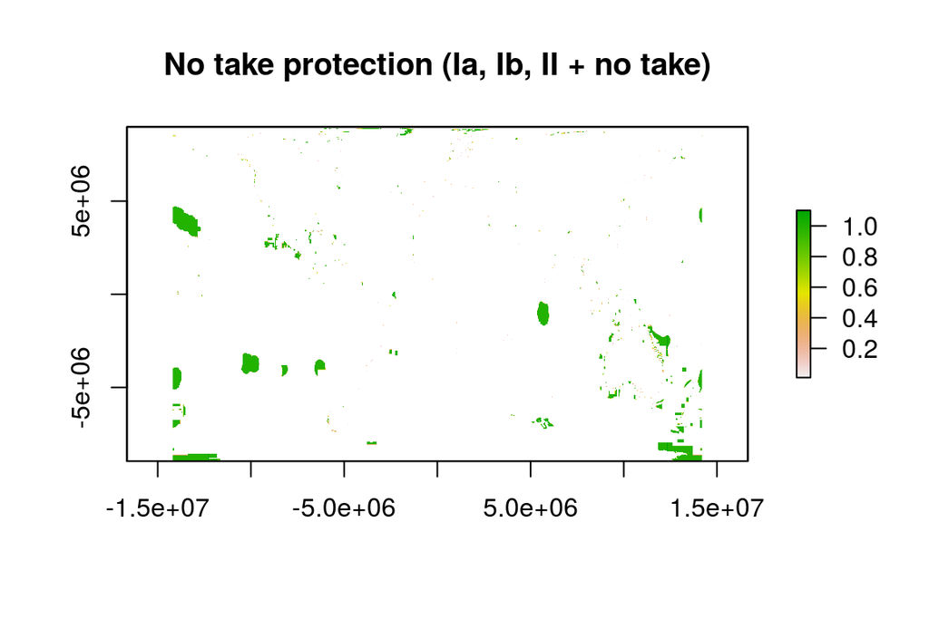

```r
wdpa_area_df <- read_csv(wdpa_cell_area_file)

notake_df <- wdpa_area_df %>%
  filter(wdpa_category <= 2) %>%
  group_by(cell_id) %>%
  summarize(mpa_pct = sum(mpa_pct))

conservation_df <- wdpa_area_df %>%
  filter(wdpa_category <= 4) %>%
  group_by(cell_id) %>%
  summarize(mpa_pct = sum(mpa_pct))

all_prot_df <- wdpa_area_df %>%
  group_by(cell_id) %>%
  summarize(mpa_pct = sum(mpa_pct))

notake_raster <- subs(rast_cell_id, notake_df, by = 'cell_id', which = 'mpa_pct')
plot(notake_raster, main = 'No take protection (Ia, Ib, II + no take)')
```

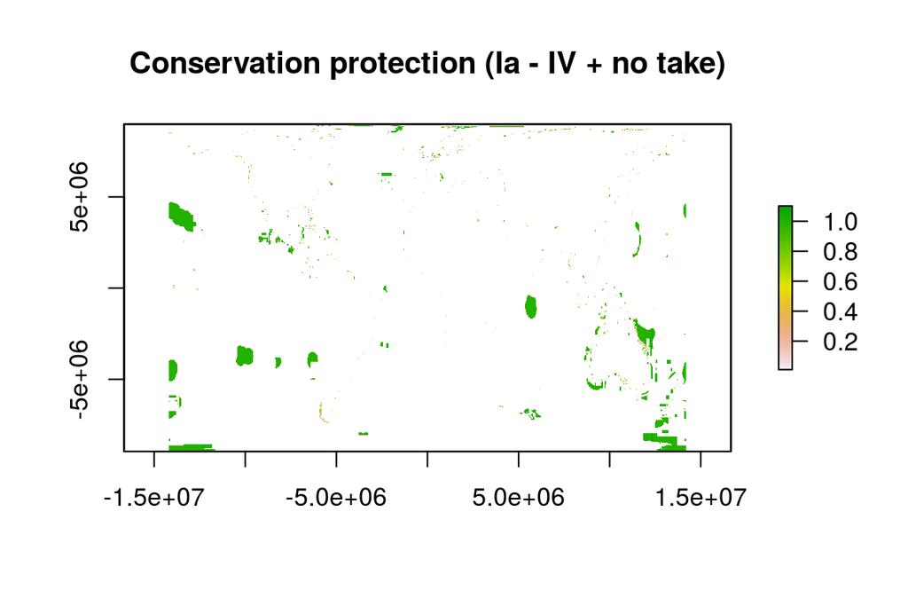

```r
conservation_raster <- subs(rast_cell_id, conservation_df, by = 'cell_id', which = 'mpa_pct')
plot(conservation_raster, main = 'Conservation protection (Ia - IV + no take)')
```

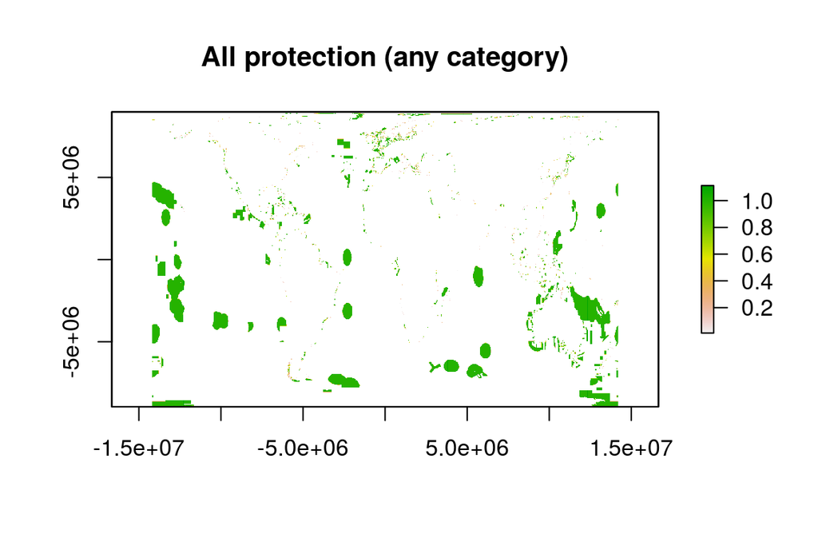

```r
all_prot_raster <- subs(rast_cell_id, all_prot_df, by = 'cell_id', which = 'mpa_pct')
plot(all_prot_raster, main = 'All protection (any category)')
```

```r
# prov_wrapup(commit_outputs = FALSE)
```